# STA 9750 Mini-Project #03: Who Goes There? US Internal Migration and Implications for Congressional Reapportionment

Author

Mary Ononye

Published

April 24, 2026

## Introduction

In this mini-project, I examine patterns of internal migration within the United States, with a focus on forecasting state congressional apportionments for the 2032 midterm elections. Using migration flow data from the American Community Survey (ACS), I will estimate state populations in 2030 and apply the Huntington-Hill apportionment method to predict how New York State’s congressional delegation may change.

Our analysis combines three data sources:

1. **ACS-1 State-to-State Migration Flows** (2023 and 2024) — who moves between states
2. **ACS-5 Metro-to-Metro Migration Flows** — which metro areas have the highest migration
3. **ACS-1 State Population Data** (2015–2024) — baseline populations for modeling

## Setup and Libraries

```r
library(tidyverse)
library(readxl)
library(jsonlite)
library(gt)
library(fs)
library(vctrs)
library(tidycensus)

data_mp03 <- fs::path("data", "mp03")
if (!fs::dir_exists(data_mp03)) fs::dir_create(data_mp03, recurse = TRUE)
```

## Task 1: Data Acquisition — State Population and Birth Information

I use `get_acs()` from the `tidycensus` package to download state-level population estimates (variable `B01003_001`) for years 2015–2024. I enable caching for efficient repeated use. Note that the 2020 1-year ACS was not released by the Census Bureau due to low response rates during the COVID-19 pandemic; 2020 is therefore excluded from this analysis.

```r
state_populations <- map_dfr(c(2015:2019, 2021:2024), function(yr) {
  get_acs(
    variables = c(total_population = "B01003_001"),
    geography = "state",
    year = yr,
    survey = "acs1",
    geometry = FALSE,
    cache_table = TRUE
  ) |>
    mutate(year = yr)
})

state_pop_tidy <- state_populations |>
  select(state_name = NAME, population = estimate, year) |>
  filter(!state_name %in% c("Puerto Rico")) |>
  mutate(state_abbr = state.abb[match(state_name, state.name)])

state_pop_tidy |>
  filter(year == 2024) |>
  arrange(desc(population)) |>
  slice_head(n = 10) |>
  gt() |>
  tab_header("Top 10 States by Population (2024 ACS-1)") |>
  fmt_integer(population) |>
  cols_label(
    state_name = "State", population = "Population",
    year = "Year", state_abbr = "Abbreviation"
  )
```

Top 10 States by Population (2024 ACS-1)

| State | Population | Year | Abbreviation |
| --- | --- | --- | --- |
| California | 39,431,263 | 2024 | CA |
| Texas | 31,290,831 | 2024 | TX |
| Florida | 23,372,215 | 2024 | FL |
| New York | 19,867,248 | 2024 | NY |
| Pennsylvania | 13,078,751 | 2024 | PA |
| Illinois | 12,710,158 | 2024 | IL |
| Ohio | 11,883,304 | 2024 | OH |
| Georgia | 11,180,878 | 2024 | GA |
| North Carolina | 11,046,024 | 2024 | NC |
| Michigan | 10,140,459 | 2024 | MI |

## Task 2: Data Acquisition — State-to-State Flows 2024

```r
state_to_state_migration_2024 <- function() {
  data_mp03 <- fs::path("data", "mp03")
  if (!fs::dir_exists(data_mp03)) fs::dir_create(data_mp03, recurse = TRUE)

  file_2024 <- fs::path(data_mp03, "State_to_State_Migration_Table_2024_T13.xlsx")
  url_2024  <- "https://www2.census.gov/programs-surveys/demo/tables/geographic-mobility/2024/state-to-state-migration/State_to_State_Migration_Table_2024_T13.xlsx"

  if (!fs::file_exists(file_2024)) {
    download.file(url_2024, destfile = file_2024, mode = "wb")
  }

  flows_table <- read_excel(
    file_2024, sheet = "Table", skip = 8,
    col_names = c("state_current", "state_1y", "population", "moe")
  ) |>
    filter(state_current %in% state.name, state_1y %in% state.name, state_current != state_1y) |>
    mutate(
      population = replace(population, population == "N", "0"),
      population = replace(population, population == "X", NA),
      population = as.integer(population)
    ) |>
    select(state_current, state_1y, population) |>
    mutate(year_current = 2024L, year_1y = 2023L)

  supp <- read_excel(
    file_2024, sheet = "Supplemental - Current Res", skip = 8,
    col_names = c("state_current", "total_pop", "moe_total", "same_residence", "moe_same",
                  "within_state", "moe_within", "from_diff_state", "moe_diff", "from_abroad", "moe_abroad")
  ) |>
    filter(state_current %in% state.name) |>
    mutate(
      same_residence = as.integer(same_residence),
      within_state   = as.integer(within_state),
      from_abroad    = as.integer(from_abroad),
      population     = same_residence + within_state + replace_na(from_abroad, 0L),
      state_1y       = state_current,
      year_current   = 2024L,
      year_1y        = 2023L
    ) |>
    select(state_current, state_1y, population, year_current, year_1y)

  bind_rows(flows_table, supp)
}

flows_2024 <- state_to_state_migration_2024()
cat("Rows:", nrow(flows_2024), "\n")
```

```
Rows: 2500
```

```r
flows_2024 |>
  filter(state_current == "New York") |>
  arrange(desc(population)) |>
  slice_head(n = 10) |>
  gt() |>
  tab_header("Top Origins of New York Residents (2024)") |>
  fmt_integer(population)
```

Top Origins of New York Residents (2024)

| state_current | state_1y | population | year_current | year_1y |
| --- | --- | --- | --- | --- |
| New York | New York | 19,380,513 | 2024 | 2023 |
| New York | New Jersey | 36,002 | 2024 | 2023 |
| New York | California | 31,367 | 2024 | 2023 |
| New York | Florida | 28,080 | 2024 | 2023 |
| New York | Pennsylvania | 23,152 | 2024 | 2023 |
| New York | Massachusetts | 17,862 | 2024 | 2023 |
| New York | Texas | 16,324 | 2024 | 2023 |
| New York | Connecticut | 15,160 | 2024 | 2023 |
| New York | Virginia | 10,310 | 2024 | 2023 |
| New York | North Carolina | 10,076 | 2024 | 2023 |

## Task 3: Data Acquisition — State-to-State Flows 2023

```r
state_to_state_migration_2023 <- function() {
  data_mp03 <- fs::path("data", "mp03")
  if (!fs::dir_exists(data_mp03)) fs::dir_create(data_mp03, recurse = TRUE)

  file_2023 <- fs::path(data_mp03, "State_to_State_Migration_Table_2023_T13.xlsx")
  url_2023  <- "https://www2.census.gov/programs-surveys/demo/tables/geographic-mobility/2023/state-to-state-migration/State_to_State_Migration_Table_2023_T13.xlsx"

  if (!fs::file_exists(file_2023)) {
    download.file(url_2023, destfile = file_2023, mode = "wb")
  }

  supp <- read_excel(file_2023, sheet = "Table", skip = 8, col_names = FALSE) |>
    select(state_current = 1, same_res = 4, within_state = 6, from_abroad = 10) |>
    filter(state_current %in% state.name) |>
    mutate(
      same_res     = as.integer(same_res),
      within_state = as.integer(within_state),
      from_abroad  = suppressWarnings(as.integer(from_abroad)),
      from_abroad  = replace_na(from_abroad, 0L),
      population   = same_res + within_state + from_abroad,
      state_1y     = state_current,
      year_current = 2023L,
      year_1y      = 2022L
    ) |>
    select(state_current, state_1y, population, year_current, year_1y)

  states_with_dc <- c(state.name[1:8], "District of Columbia", state.name[9:50])
  raw            <- read_excel(file_2023, sheet = "Table", skip = 8, col_names = FALSE)
  estimate_cols  <- seq(10, 10 + (51 * 2) - 2, by = 2)

  flow_data <- raw |>
    select(state_current = 1, all_of(estimate_cols)) |>
    filter(state_current %in% state.name)

  colnames(flow_data) <- c("state_current", states_with_dc)

  part2 <- flow_data |>
    pivot_longer(cols = all_of(states_with_dc), names_to = "state_1y", values_to = "population") |>
    filter(state_current != state_1y, state_1y != "District of Columbia", !is.na(population)) |>
    mutate(
      population   = replace(population, population == "N", "0"),
      population   = replace(population, population == "X", NA),
      population   = as.integer(population),
      year_current = 2023L,
      year_1y      = 2022L
    ) |>
    select(state_current, state_1y, population, year_current, year_1y)

  bind_rows(supp, part2)
}

flows_2023 <- state_to_state_migration_2023()
cat("Rows:", nrow(flows_2023), "\n")
```

```
Rows: 2500
```

## Task 4: Combined State-to-State Flows

```r
state_to_state_migration <- function() {
  bind_rows(state_to_state_migration_2024(), state_to_state_migration_2023())
}

all_flows <- state_to_state_migration()
cat("Total rows:", nrow(all_flows), "\n")
```

```
Total rows: 5000
```

```r
all_flows |>
  filter(state_current == "Alabama") |>
  arrange(year_current, state_1y) |>
  slice_head(n = 4) |>
  gt() |>
  tab_header("Alabama Sample Rows (confirming format)") |>
  fmt_integer(population)
```

Alabama Sample Rows (confirming format)

| state_current | state_1y | population | year_current | year_1y |
| --- | --- | --- | --- | --- |
| Alabama | Alabama | 4,920,737 | 2023 | 2022 |
| Alabama | Alaska | 780 | 2023 | 2022 |
| Alabama | Arizona | 4,470 | 2023 | 2022 |
| Alabama | Arkansas | 1,584 | 2023 | 2022 |

## Task 5: Metro-to-Metro Migration Flows

```r
metro_to_metro_migration <- function() {
  data_mp03  <- fs::path("data", "mp03")
  if (!fs::dir_exists(data_mp03)) fs::dir_create(data_mp03, recurse = TRUE)

  metro_file <- fs::path(data_mp03, "metro_migration_acs5.json")
  api_url    <- paste0(
    "https://api.census.gov/data/2020/acs/flows?",
    "get=MOVEDIN,MOVEDOUT,FULL1_NAME,FULL2_NAME",
    "&for=metropolitan%20statistical%20area/micropolitan%20statistical%20area:*"
  )

  if (!fs::file_exists(metro_file)) {
    download.file(api_url, destfile = metro_file, mode = "wb")
  }

  raw <- read_json(metro_file, simplifyVector = TRUE)

  move_row_to_colnames <- function(X, row = 1) {
    X    <- as_tibble(X)
    Xrow <- X[row, ]
    X    <- X[-row, ]
    colnames(X) <- Xrow
    readr::type_convert(X)
  }

  metro_df <- move_row_to_colnames(raw) |>
    select(metro1 = FULL1_NAME, metro2 = FULL2_NAME, moved_in = MOVEDIN, moved_out = MOVEDOUT) |>
    filter(!is.na(moved_in), !is.na(moved_out))

  pull_state_from_metro <- function(metro_name) {
    str_extract(metro_name, ".*, (\\S{2})[-[:alpha:]]* Metro Area", group = 1)
  }

  metro_df |>
    mutate(state1 = pull_state_from_metro(metro1), state2 = pull_state_from_metro(metro2))
}

metro_flows <- metro_to_metro_migration()

metro_flows |>
  arrange(desc(moved_in)) |>
  slice_head(n = 10) |>
  gt() |>
  tab_header("Top 10 Metro-to-Metro Flows by In-Migration") |>
  fmt_integer(c(moved_in, moved_out))
```

Top 10 Metro-to-Metro Flows by In-Migration

| metro1 | metro2 | moved_in | moved_out | state1 | state2 |
| --- | --- | --- | --- | --- | --- |
| Riverside-San Bernardino-Ontario, CA Metro Area | Los Angeles-Long Beach-Anaheim, CA Metro Area | 84,332 | 39,795 | CA | CA |
| Los Angeles-Long Beach-Anaheim, CA Metro Area | Riverside-San Bernardino-Ontario, CA Metro Area | 39,795 | 84,332 | CA | CA |
| Philadelphia-Camden-Wilmington, PA-NJ-DE-MD Metro Area | New York-Newark-Jersey City, NY-NJ-PA Metro Area | 35,254 | 19,600 | PA | NY |
| Dallas-Fort Worth-Arlington, TX Metro Area | Outside Metro Area within U.S. or Puerto Rico | 33,190 | 44,775 | TX | NA |
| Baltimore-Columbia-Towson, MD Metro Area | Washington-Arlington-Alexandria, DC-VA-MD-WV Metro Area | 32,189 | 28,038 | MD | DC |
| San Francisco-Oakland-Berkeley, CA Metro Area | San Jose-Sunnyvale-Santa Clara, CA Metro Area | 30,099 | 20,299 | CA | CA |
| Washington-Arlington-Alexandria, DC-VA-MD-WV Metro Area | Baltimore-Columbia-Towson, MD Metro Area | 28,038 | 32,189 | DC | MD |
| Houston-The Woodlands-Sugar Land, TX Metro Area | Outside Metro Area within U.S. or Puerto Rico | 24,732 | 33,158 | TX | NA |
| Minneapolis-St. Paul-Bloomington, MN-WI Metro Area | Outside Metro Area within U.S. or Puerto Rico | 24,636 | 26,466 | MN | NA |
| Atlanta-Sandy Springs-Alpharetta, GA Metro Area | Outside Metro Area within U.S. or Puerto Rico | 24,130 | 36,049 | GA | NA |

## Task 6: Exploratory Data Analysis

### 6.1 States with Highest Net Population Growth Rates (Past Decade)

```r
pop_growth <- state_pop_tidy |>
  filter(year %in% c(2015, 2024)) |>
  pivot_wider(names_from = year, values_from = population, names_prefix = "pop_") |>
  mutate(growth_rate = (pop_2024 - pop_2015) / pop_2015, net_growth = pop_2024 - pop_2015) |>
  arrange(desc(growth_rate))

pop_growth |>
  slice_head(n = 10) |>
  select(state_name, pop_2015, pop_2024, growth_rate, net_growth) |>
  gt() |>
  tab_header("Top 10 States by Population Growth Rate (2015–2024)") |>
  fmt_percent(growth_rate, decimals = 1) |>
  fmt_integer(c(pop_2015, pop_2024, net_growth)) |>
  cols_label(state_name = "State", pop_2015 = "Population (2015)",
             pop_2024 = "Population (2024)", growth_rate = "Growth Rate", net_growth = "Net Growth")
```

Top 10 States by Population Growth Rate (2015–2024)

| State | Population (2015) | Population (2024) | Growth Rate | Net Growth |
| --- | --- | --- | --- | --- |
| Idaho | 1,654,930 | 2,001,619 | 20.9% | 346,689 |
| Utah | 2,995,919 | 3,503,613 | 16.9% | 507,694 |
| Florida | 20,271,272 | 23,372,215 | 15.3% | 3,100,943 |
| Texas | 27,469,114 | 31,290,831 | 13.9% | 3,821,717 |
| Nevada | 2,890,845 | 3,267,467 | 13.0% | 376,622 |
| South Carolina | 4,896,146 | 5,478,831 | 11.9% | 582,685 |
| Delaware | 945,934 | 1,051,917 | 11.2% | 105,983 |
| Arizona | 6,828,065 | 7,582,384 | 11.0% | 754,319 |
| Washington | 7,170,351 | 7,958,180 | 11.0% | 787,829 |
| Montana | 1,032,949 | 1,137,233 | 10.1% | 104,284 |

Florida, Texas, and Mountain West states (Idaho, Montana, Utah) have seen the fastest population growth over the past decade, driven substantially by domestic in-migration.

### 6.2 Migration Into and Out of New York State

```r
ny_inflows <- all_flows |>
  filter(state_current == "New York", state_1y != "New York", year_current == 2024) |>
  arrange(desc(population)) |>
  slice_head(n = 10)

ny_inflows |>
  gt() |>
  tab_header("Top Origins of People Who Moved to New York (2024)") |>
  fmt_integer(population) |>
  cols_label(state_current = "Destination", state_1y = "Origin",
             population = "People", year_current = "Year", year_1y = "Prior Year")
```

Top Origins of People Who Moved to New York (2024)

| Destination | Origin | People | Year | Prior Year |
| --- | --- | --- | --- | --- |
| New York | New Jersey | 36,002 | 2024 | 2023 |
| New York | California | 31,367 | 2024 | 2023 |
| New York | Florida | 28,080 | 2024 | 2023 |
| New York | Pennsylvania | 23,152 | 2024 | 2023 |
| New York | Massachusetts | 17,862 | 2024 | 2023 |
| New York | Texas | 16,324 | 2024 | 2023 |
| New York | Connecticut | 15,160 | 2024 | 2023 |
| New York | Virginia | 10,310 | 2024 | 2023 |
| New York | North Carolina | 10,076 | 2024 | 2023 |
| New York | Maryland | 8,400 | 2024 | 2023 |

```r
ny_outflows <- all_flows |>
  filter(state_1y == "New York", state_current != "New York", year_current == 2024) |>
  arrange(desc(population)) |>
  slice_head(n = 10)

ny_outflows |>
  gt() |>
  tab_header("Top Destinations for People Leaving New York (2024)") |>
  fmt_integer(population) |>
  cols_label(state_current = "Destination", state_1y = "Origin",
             population = "People", year_current = "Year", year_1y = "Prior Year")
```

Top Destinations for People Leaving New York (2024)

| Destination | Origin | People | Year | Prior Year |
| --- | --- | --- | --- | --- |
| New Jersey | New York | 56,799 | 2024 | 2023 |
| Florida | New York | 50,661 | 2024 | 2023 |
| Pennsylvania | New York | 29,274 | 2024 | 2023 |
| Texas | New York | 28,233 | 2024 | 2023 |
| Connecticut | New York | 25,095 | 2024 | 2023 |
| California | New York | 24,927 | 2024 | 2023 |
| Massachusetts | New York | 18,697 | 2024 | 2023 |
| South Carolina | New York | 18,324 | 2024 | 2023 |
| North Carolina | New York | 17,978 | 2024 | 2023 |
| Virginia | New York | 16,364 | 2024 | 2023 |

People moving **to** New York most commonly come from New Jersey, California, and Florida. People leaving New York most commonly head to **New Jersey, Florida, and Pennsylvania**, reinforcing the well-documented “New York to Florida” retirement and cost-of-living migration pattern.

### 6.3 Migration Into and Out of New York City (Metro)

```r
nyc_metro_in <- metro_flows |>
  filter(str_detect(metro1, "New York-Newark")) |>
  arrange(desc(moved_in)) |>
  slice_head(n = 10)

nyc_metro_in |>
  select(metro1, metro2, moved_in, moved_out) |>
  gt() |>
  tab_header("Top Origins of People Moving INTO NYC Metro") |>
  fmt_integer(c(moved_in, moved_out))
```

Top Origins of People Moving INTO NYC Metro

| metro1 | metro2 | moved_in | moved_out |
| --- | --- | --- | --- |
| New York-Newark-Jersey City, NY-NJ-PA Metro Area | Philadelphia-Camden-Wilmington, PA-NJ-DE-MD Metro Area | 19,600 | 35,254 |
| New York-Newark-Jersey City, NY-NJ-PA Metro Area | Outside Metro Area within U.S. or Puerto Rico | 11,701 | 29,403 |
| New York-Newark-Jersey City, NY-NJ-PA Metro Area | Washington-Arlington-Alexandria, DC-VA-MD-WV Metro Area | 11,162 | 17,558 |
| New York-Newark-Jersey City, NY-NJ-PA Metro Area | Boston-Cambridge-Newton, MA-NH Metro Area | 10,019 | 15,162 |
| New York-Newark-Jersey City, NY-NJ-PA Metro Area | Los Angeles-Long Beach-Anaheim, CA Metro Area | 9,761 | 17,107 |
| New York-Newark-Jersey City, NY-NJ-PA Metro Area | Poughkeepsie-Newburgh-MiddleTown, NY Metro Area | 9,492 | 15,475 |
| New York-Newark-Jersey City, NY-NJ-PA Metro Area | Miami-Fort Lauderdale-Pompano Beach, FL Metro Area | 8,085 | 22,411 |
| New York-Newark-Jersey City, NY-NJ-PA Metro Area | Bridgeport-Stamford-Norwalk, CT Metro Area | 7,534 | 16,709 |
| New York-Newark-Jersey City, NY-NJ-PA Metro Area | Trenton-Princeton, NJ Metro Area | 7,208 | 12,735 |
| New York-Newark-Jersey City, NY-NJ-PA Metro Area | San Francisco-Oakland-Berkeley, CA Metro Area | 6,923 | 9,381 |

```r
nyc_metro_out <- metro_flows |>
  filter(str_detect(metro1, "New York-Newark")) |>
  arrange(desc(moved_out)) |>
  slice_head(n = 10)

nyc_metro_out |>
  select(metro1, metro2, moved_in, moved_out) |>
  gt() |>
  tab_header("Top Destinations for People Leaving NYC Metro") |>
  fmt_integer(c(moved_in, moved_out))
```

Top Destinations for People Leaving NYC Metro

| metro1 | metro2 | moved_in | moved_out |
| --- | --- | --- | --- |
| New York-Newark-Jersey City, NY-NJ-PA Metro Area | Philadelphia-Camden-Wilmington, PA-NJ-DE-MD Metro Area | 19,600 | 35,254 |
| New York-Newark-Jersey City, NY-NJ-PA Metro Area | Outside Metro Area within U.S. or Puerto Rico | 11,701 | 29,403 |
| New York-Newark-Jersey City, NY-NJ-PA Metro Area | Miami-Fort Lauderdale-Pompano Beach, FL Metro Area | 8,085 | 22,411 |
| New York-Newark-Jersey City, NY-NJ-PA Metro Area | Washington-Arlington-Alexandria, DC-VA-MD-WV Metro Area | 11,162 | 17,558 |
| New York-Newark-Jersey City, NY-NJ-PA Metro Area | Los Angeles-Long Beach-Anaheim, CA Metro Area | 9,761 | 17,107 |
| New York-Newark-Jersey City, NY-NJ-PA Metro Area | Bridgeport-Stamford-Norwalk, CT Metro Area | 7,534 | 16,709 |
| New York-Newark-Jersey City, NY-NJ-PA Metro Area | Poughkeepsie-Newburgh-MiddleTown, NY Metro Area | 9,492 | 15,475 |
| New York-Newark-Jersey City, NY-NJ-PA Metro Area | Boston-Cambridge-Newton, MA-NH Metro Area | 10,019 | 15,162 |
| New York-Newark-Jersey City, NY-NJ-PA Metro Area | Atlanta-Sandy Springs-Alpharetta, GA Metro Area | 4,876 | 12,928 |
| New York-Newark-Jersey City, NY-NJ-PA Metro Area | Trenton-Princeton, NJ Metro Area | 7,208 | 12,735 |

### 6.4 States with Highest In-Migration, Out-Migration, and Net Migration

```r
state_migration_summary <- all_flows |>
  filter(state_current != state_1y) |>
  group_by(state_current, year_current) |>
  summarize(in_migration = sum(population, na.rm = TRUE), .groups = "drop") |>
  rename(state = state_current, year = year_current) |>
  full_join(
    all_flows |>
      filter(state_current != state_1y) |>
      group_by(state_1y, year_current) |>
      summarize(out_migration = sum(population, na.rm = TRUE), .groups = "drop") |>
      rename(state = state_1y, year = year_current),
    by = c("state", "year")
  ) |>
  mutate(net_migration = in_migration - out_migration)

state_migration_summary |>
  filter(year == 2024) |>
  arrange(desc(net_migration)) |>
  slice_head(n = 10) |>
  gt() |>
  tab_header("States with Highest Net In-Migration (2024)") |>
  fmt_integer(c(in_migration, out_migration, net_migration))
```

States with Highest Net In-Migration (2024)

| state | year | in_migration | out_migration | net_migration |
| --- | --- | --- | --- | --- |
| Texas | 2024 | 553,869 | 482,029 | 71,840 |
| Florida | 2024 | 571,998 | 505,072 | 66,926 |
| North Carolina | 2024 | 297,704 | 239,780 | 57,924 |
| Arizona | 2024 | 234,723 | 178,678 | 56,045 |
| South Carolina | 2024 | 189,282 | 134,348 | 54,934 |
| Nevada | 2024 | 129,109 | 88,898 | 40,211 |
| Georgia | 2024 | 265,364 | 228,039 | 37,325 |
| Tennessee | 2024 | 191,386 | 155,499 | 35,887 |
| Oklahoma | 2024 | 106,621 | 72,461 | 34,160 |
| Alabama | 2024 | 119,767 | 97,317 | 22,450 |

```r
state_migration_summary |>
  filter(year == 2024) |>
  arrange(net_migration) |>
  slice_head(n = 10) |>
  gt() |>
  tab_header("States with Highest Net Out-Migration (2024)") |>
  fmt_integer(c(in_migration, out_migration, net_migration))
```

States with Highest Net Out-Migration (2024)

| state | year | in_migration | out_migration | net_migration |
| --- | --- | --- | --- | --- |
| California | 2024 | 404,745 | 656,646 | −251,901 |
| New York | 2024 | 280,073 | 412,187 | −132,114 |
| Illinois | 2024 | 199,235 | 279,613 | −80,378 |
| New Jersey | 2024 | 149,512 | 211,969 | −62,457 |
| Massachusetts | 2024 | 150,513 | 180,497 | −29,984 |
| Colorado | 2024 | 181,683 | 204,323 | −22,640 |
| Pennsylvania | 2024 | 232,208 | 247,858 | −15,650 |
| Louisiana | 2024 | 70,847 | 82,616 | −11,769 |
| Alaska | 2024 | 29,456 | 39,842 | −10,386 |
| Iowa | 2024 | 59,199 | 69,417 | −10,218 |

### 6.5 Metro Areas with Highest Migration

```r
metro_summary <- metro_flows |>
  group_by(metro1) |>
  summarize(
    total_in  = sum(moved_in,  na.rm = TRUE),
    total_out = sum(moved_out, na.rm = TRUE),
    net       = total_in - total_out,
    .groups = "drop"
  )

metro_summary |>
  arrange(desc(total_in)) |>
  slice_head(n = 10) |>
  gt() |>
  tab_header("Metro Areas with Highest Total In-Migration") |>
  fmt_integer(c(total_in, total_out, net))
```

Metro Areas with Highest Total In-Migration

| metro1 | total_in | total_out | net |
| --- | --- | --- | --- |
| Los Angeles-Long Beach-Anaheim, CA Metro Area | 250,693 | 393,231 | −142,538 |
| Dallas-Fort Worth-Arlington, TX Metro Area | 248,701 | 225,266 | 23,435 |
| New York-Newark-Jersey City, NY-NJ-PA Metro Area | 247,545 | 520,039 | −272,494 |
| Washington-Arlington-Alexandria, DC-VA-MD-WV Metro Area | 225,060 | 270,979 | −45,919 |
| Phoenix-Mesa-Chandler, AZ Metro Area | 204,986 | 147,065 | 57,921 |
| Atlanta-Sandy Springs-Alpharetta, GA Metro Area | 204,029 | 205,499 | −1,470 |
| Houston-The Woodlands-Sugar Land, TX Metro Area | 188,965 | 184,396 | 4,569 |
| Riverside-San Bernardino-Ontario, CA Metro Area | 185,697 | 148,771 | 36,926 |
| Chicago-Naperville-Elgin, IL-IN-WI Metro Area | 174,938 | 281,352 | −106,414 |
| San Francisco-Oakland-Berkeley, CA Metro Area | 168,511 | 215,668 | −47,157 |

```r
metro_summary |>
  arrange(desc(net)) |>
  slice_head(n = 10) |>
  gt() |>
  tab_header("Metro Areas with Highest Net In-Migration") |>
  fmt_integer(c(total_in, total_out, net))
```

Metro Areas with Highest Net In-Migration

| metro1 | total_in | total_out | net |
| --- | --- | --- | --- |
| Phoenix-Mesa-Chandler, AZ Metro Area | 204,986 | 147,065 | 57,921 |
| Riverside-San Bernardino-Ontario, CA Metro Area | 185,697 | 148,771 | 36,926 |
| Austin-Round Rock-GeorgeTown, TX Metro Area | 128,968 | 97,392 | 31,576 |
| Tampa-St. Petersburg-Clearwater, FL Metro Area | 147,150 | 116,383 | 30,767 |
| Las Vegas-Henderson-Paradise, NV Metro Area | 102,177 | 72,541 | 29,636 |
| Orlando-Kissimmee-Sanford, FL Metro Area | 142,828 | 115,061 | 27,767 |
| Dallas-Fort Worth-Arlington, TX Metro Area | 248,701 | 225,266 | 23,435 |
| North Port-Sarasota-Bradenton, FL Metro Area | 52,384 | 33,418 | 18,966 |
| Columbia, SC Metro Area | 57,009 | 38,222 | 18,787 |
| Deltona-Daytona Beach-Ormond Beach, FL Metro Area | 44,656 | 26,305 | 18,351 |

### 6.6 States with Lowest Proportional In-Migration (Most “Sticky”)

```r
total_pop_2024 <- state_pop_tidy |>
  filter(year == 2024) |>
  select(state_name, population)

in_movers_2024 <- all_flows |>
  filter(state_current != state_1y, year_current == 2024) |>
  group_by(state_current) |>
  summarize(in_movers = sum(population, na.rm = TRUE)) |>
  rename(state_name = state_current)

sticky_states <- total_pop_2024 |>
  left_join(in_movers_2024, by = "state_name") |>
  mutate(in_mover_frac = in_movers / population, stayed_frac = 1 - in_mover_frac) |>
  arrange(desc(stayed_frac))

sticky_states |>
  slice_head(n = 10) |>
  gt() |>
  tab_header("Most 'Sticky' States: Lowest Proportional In-Migration (2024)") |>
  fmt_percent(c(in_mover_frac, stayed_frac), decimals = 2) |>
  fmt_integer(c(population, in_movers))
```

Most 'Sticky' States: Lowest Proportional In-Migration (2024)

| state_name | population | in_movers | in_mover_frac | stayed_frac |
| --- | --- | --- | --- | --- |
| California | 39,431,263 | 404,745 | 1.03% | 98.97% |
| Michigan | 10,140,459 | 139,882 | 1.38% | 98.62% |
| New York | 19,867,248 | 280,073 | 1.41% | 98.59% |
| Louisiana | 4,597,740 | 70,847 | 1.54% | 98.46% |
| Illinois | 12,710,158 | 199,235 | 1.57% | 98.43% |
| New Jersey | 9,500,851 | 149,512 | 1.57% | 98.43% |
| Ohio | 11,883,304 | 197,471 | 1.66% | 98.34% |
| Texas | 31,290,831 | 553,869 | 1.77% | 98.23% |
| Pennsylvania | 13,078,751 | 232,208 | 1.78% | 98.22% |
| Minnesota | 5,793,151 | 103,924 | 1.79% | 98.21% |

### 6.7 States Where Net Migration is the Largest Share of Population Growth

```r
pop_change <- state_pop_tidy |>
  filter(year %in% c(2023, 2024)) |>
  pivot_wider(names_from = year, values_from = population, names_prefix = "pop_") |>
  mutate(total_growth = pop_2024 - pop_2023)

net_mig_2024 <- state_migration_summary |>
  filter(year == 2024) |>
  rename(state_name = state)

mig_share <- pop_change |>
  left_join(net_mig_2024, by = "state_name") |>
  mutate(mig_share_of_growth = net_migration / total_growth) |>
  filter(total_growth > 0) |>
  arrange(desc(mig_share_of_growth))

mig_share |>
  slice_head(n = 10) |>
  select(state_name, total_growth, net_migration, mig_share_of_growth) |>
  gt() |>
  tab_header("States Where Migration Drives Growth Most (2023–2024)") |>
  fmt_integer(c(total_growth, net_migration)) |>
  fmt_percent(mig_share_of_growth, decimals = 1)
```

States Where Migration Drives Growth Most (2023–2024)

| state_name | total_growth | net_migration | mig_share_of_growth |
| --- | --- | --- | --- |
| Vermont | 1,029 | 9,231 | 897.1% |
| Mississippi | 3,355 | 10,796 | 321.8% |
| Wyoming | 3,561 | 6,466 | 181.6% |
| New Hampshire | 6,978 | 6,697 | 96.0% |
| Maine | 9,290 | 8,493 | 91.4% |
| Oklahoma | 41,569 | 34,160 | 82.2% |
| North Dakota | 12,642 | 7,532 | 59.6% |
| Nevada | 73,291 | 40,211 | 54.9% |
| South Carolina | 105,276 | 54,934 | 52.2% |
| Alabama | 49,231 | 22,450 | 45.6% |

### 6.8 New York State Specific Analysis

```r
all_flows |>
  filter(state_current == "New York", state_1y != "New York", year_current == 2024) |>
  arrange(desc(population)) |>
  slice_head(n = 5) |>
  gt() |>
  tab_header("Top 5 States Sending Migrants to New York (2024)") |>
  fmt_integer(population)
```

Top 5 States Sending Migrants to New York (2024)

| state_current | state_1y | population | year_current | year_1y |
| --- | --- | --- | --- | --- |
| New York | New Jersey | 36,002 | 2024 | 2023 |
| New York | California | 31,367 | 2024 | 2023 |
| New York | Florida | 28,080 | 2024 | 2023 |
| New York | Pennsylvania | 23,152 | 2024 | 2023 |
| New York | Massachusetts | 17,862 | 2024 | 2023 |

```r
all_flows |>
  filter(state_1y == "New York", state_current != "New York", year_current == 2024) |>
  arrange(desc(population)) |>
  slice_head(n = 5) |>
  gt() |>
  tab_header("Top 5 Destinations for People Leaving New York (2024)") |>
  fmt_integer(population)
```

Top 5 Destinations for People Leaving New York (2024)

| state_current | state_1y | population | year_current | year_1y |
| --- | --- | --- | --- | --- |
| New Jersey | New York | 56,799 | 2024 | 2023 |
| Florida | New York | 50,661 | 2024 | 2023 |
| Pennsylvania | New York | 29,274 | 2024 | 2023 |
| Texas | New York | 28,233 | 2024 | 2023 |
| Connecticut | New York | 25,095 | 2024 | 2023 |

```r
nyc_metro_flows <- metro_flows |> filter(str_detect(metro1, "New York-Newark"))

nyc_metro_flows |>
  arrange(desc(moved_in)) |>
  slice_head(n = 5) |>
  select(metro2, moved_in, moved_out) |>
  gt() |>
  tab_header("Top Origins for NYC Metro In-Migration") |>
  fmt_integer(c(moved_in, moved_out))
```

Top Origins for NYC Metro In-Migration

| metro2 | moved_in | moved_out |
| --- | --- | --- |
| Philadelphia-Camden-Wilmington, PA-NJ-DE-MD Metro Area | 19,600 | 35,254 |
| Outside Metro Area within U.S. or Puerto Rico | 11,701 | 29,403 |
| Washington-Arlington-Alexandria, DC-VA-MD-WV Metro Area | 11,162 | 17,558 |
| Boston-Cambridge-Newton, MA-NH Metro Area | 10,019 | 15,162 |
| Los Angeles-Long Beach-Anaheim, CA Metro Area | 9,761 | 17,107 |

```r
nyc_metro_flows |>
  arrange(desc(moved_out)) |>
  slice_head(n = 5) |>
  select(metro2, moved_in, moved_out) |>
  gt() |>
  tab_header("Top Destinations for NYC Metro Out-Migrants") |>
  fmt_integer(c(moved_in, moved_out))
```

Top Destinations for NYC Metro Out-Migrants

| metro2 | moved_in | moved_out |
| --- | --- | --- |
| Philadelphia-Camden-Wilmington, PA-NJ-DE-MD Metro Area | 19,600 | 35,254 |
| Outside Metro Area within U.S. or Puerto Rico | 11,701 | 29,403 |
| Miami-Fort Lauderdale-Pompano Beach, FL Metro Area | 8,085 | 22,411 |
| Washington-Arlington-Alexandria, DC-VA-MD-WV Metro Area | 11,162 | 17,558 |
| Los Angeles-Long Beach-Anaheim, CA Metro Area | 9,761 | 17,107 |

```r
nyc_as_pct <- metro_flows |>
  filter(str_detect(metro1, "New York-Newark")) |>
  group_by(metro2) |>
  summarize(nyc_to_dest = sum(moved_out, na.rm = TRUE), .groups = "drop") |>
  left_join(
    metro_flows |>
      group_by(metro2 = metro1) |>
      summarize(total_in = sum(moved_in, na.rm = TRUE), .groups = "drop"),
    by = "metro2"
  ) |>
  mutate(nyc_share = nyc_to_dest / total_in) |>
  filter(!is.na(nyc_share)) |>
  arrange(desc(nyc_share)) |>
  slice_head(n = 10)

nyc_as_pct |>
  gt() |>
  tab_header("Metro Areas with Highest Share of In-Migrants from NYC") |>
  fmt_percent(nyc_share, decimals = 1) |>
  fmt_integer(c(nyc_to_dest, total_in))
```

Metro Areas with Highest Share of In-Migrants from NYC

| metro2 | nyc_to_dest | total_in | nyc_share |
| --- | --- | --- | --- |
| Trenton-Princeton, NJ Metro Area | 12,735 | 23,520 | 54.1% |
| Poughkeepsie-Newburgh-MiddleTown, NY Metro Area | 15,475 | 31,141 | 49.7% |
| Bridgeport-Stamford-Norwalk, CT Metro Area | 16,709 | 34,412 | 48.6% |
| Kingston, NY Metro Area | 3,185 | 8,195 | 38.9% |
| East Stroudsburg, PA Metro Area | 4,077 | 10,677 | 38.2% |
| Binghamton, NY Metro Area | 4,048 | 11,754 | 34.4% |
| Allentown-Bethlehem-Easton, PA-NJ Metro Area | 12,284 | 36,790 | 33.4% |
| Scranton--Wilkes-Barre, PA Metro Area | 6,411 | 22,334 | 28.7% |
| Utica-Rome, NY Metro Area | 3,107 | 11,016 | 28.2% |
| Ithaca, NY Metro Area | 3,633 | 13,388 | 27.1% |

Miami, Philadelphia, and Boston consistently appear as both major sources and destinations for NYC metro migration, reflecting strong regional and lifestyle-driven movement corridors.

## Task 7: Population Projections

We use the simple migration model from the project description to forecast state populations through 2030.

```r
fit_model_params <- function(flows_year, pop_year_t, pop_year_t1, year_t, year_t1) {
  P_t   <- sum(pop_year_t$population,  na.rm = TRUE)
  P_t1  <- sum(pop_year_t1$population, na.rm = TRUE)
  alpha <- (P_t1 - P_t) / P_t

  flows_clean <- flows_year |>
    filter(state_current != state_1y, year_current == year_t1, year_1y == year_t) |>
    rename(state_origin = state_1y, state_dest = state_current, n_moved = population)

  pop_t_named  <- pop_year_t  |> select(state_name, pop_t  = population)
  pop_t1_named <- pop_year_t1 |> select(state_name, pop_t1 = population)

  mu_df <- flows_clean |>
    left_join(pop_t_named,  by = c("state_origin" = "state_name")) |>
    left_join(pop_t1_named, by = c("state_dest"   = "state_name")) |>
    mutate(mu = n_moved / (pop_t * pop_t1)) |>
    filter(!is.na(mu)) |>
    select(state_origin, state_dest, mu)

  list(alpha = alpha, mu = mu_df)
}

get_pop_year <- function(yr) {
  state_pop_tidy |>
    filter(year == yr) |>
    select(state_name, population) |>
    filter(state_name %in% state.name)
}

pop_2022 <- get_pop_year(2022)
pop_2023 <- get_pop_year(2023)
pop_2024 <- get_pop_year(2024)

flows_2024_only <- all_flows |> filter(year_current == 2024)
params_2024     <- fit_model_params(flows_2024_only, pop_2023, pop_2024, 2023L, 2024L)

flows_2023_only <- all_flows |> filter(year_current == 2023)
params_2023     <- fit_model_params(flows_2023_only, pop_2022, pop_2023, 2022L, 2023L)

alpha_avg <- mean(c(params_2024$alpha, params_2023$alpha))

mu_avg <- full_join(
  params_2024$mu |> rename(mu_2024 = mu),
  params_2023$mu |> rename(mu_2023 = mu),
  by = c("state_origin", "state_dest")
) |>
  mutate(
    mu_2024 = replace_na(mu_2024, 0),
    mu_2023 = replace_na(mu_2023, 0),
    mu      = (mu_2024 + mu_2023) / 2
  ) |>
  select(state_origin, state_dest, mu)

cat("Average national natural growth rate (alpha):", round(alpha_avg * 100, 4), "%\n")
```

```
Average national natural growth rate (alpha): 1.0174 %
```

```r
project_one_year <- function(pop_df, alpha, mu_df) {
  net_mig <- mu_df |>
    left_join(pop_df |> rename(pop_origin = population), by = c("state_origin" = "state_name")) |>
    left_join(pop_df |> rename(pop_dest   = population), by = c("state_dest"   = "state_name")) |>
    mutate(flow = mu * pop_origin * pop_dest) |>
    group_by(state_dest) |>
    summarize(in_flow = sum(flow, na.rm = TRUE), .groups = "drop") |>
    full_join(
      mu_df |>
        left_join(pop_df |> rename(pop_origin = population), by = c("state_origin" = "state_name")) |>
        left_join(pop_df |> rename(pop_dest   = population), by = c("state_dest"   = "state_name")) |>
        mutate(flow = mu * pop_origin * pop_dest) |>
        group_by(state_origin) |>
        summarize(out_flow = sum(flow, na.rm = TRUE), .groups = "drop"),
      by = c("state_dest" = "state_origin")
    ) |>
    mutate(net_flow = replace_na(in_flow, 0) - replace_na(out_flow, 0)) |>
    rename(state_name = state_dest)

  pop_df |>
    left_join(net_mig, by = "state_name") |>
    mutate(
      population = population * (1 + alpha) + replace_na(net_flow, 0),
      population = round(population)
    ) |>
    select(state_name, population)
}

projections <- list()
current_pop <- pop_2024

for (yr in 2025:2030) {
  current_pop <- project_one_year(current_pop, alpha_avg, mu_avg)
  projections[[as.character(yr)]] <- current_pop |> mutate(year = yr)
}

proj_df   <- bind_rows(projections)
proj_2030 <- proj_df |> filter(year == 2030) |> arrange(desc(population))

proj_2030 |>
  slice_head(n = 15) |>
  gt() |>
  tab_header("Projected State Populations in 2030") |>
  fmt_integer(population) |>
  cols_label(state_name = "State", population = "Projected Population", year = "Year")
```

Projected State Populations in 2030

| State | Projected Population | Year |
| --- | --- | --- |
| California | 40,202,407 | 2030 |
| Texas | 33,899,698 | 2030 |
| Florida | 25,419,555 | 2030 |
| New York | 20,111,521 | 2030 |
| Pennsylvania | 13,738,718 | 2030 |
| Illinois | 12,941,902 | 2030 |
| Ohio | 12,707,393 | 2030 |
| North Carolina | 12,291,116 | 2030 |
| Georgia | 12,206,877 | 2030 |
| Michigan | 10,733,580 | 2030 |
| New Jersey | 9,656,827 | 2030 |
| Virginia | 9,418,941 | 2030 |
| Washington | 8,487,685 | 2030 |
| Arizona | 8,446,846 | 2030 |
| Tennessee | 7,872,830 | 2030 |

```r
ny_proj <- proj_df |> filter(state_name == "New York")
cat("\nNew York projected 2030 population:",
    format(ny_proj |> filter(year == 2030) |> pull(population), big.mark = ","), "\n")
```

```
New York projected 2030 population: 20,111,521
```

## Task 8: Congressional Reapportionment Using Huntington-Hill

```r
MAX_DISTRICTS <- 100
N_DISTRICTS   <- 435

huntington_hill <- function(pop_df) {
  pop_df |>
    expand_grid(cd = seq(0, MAX_DISTRICTS)) |>
    mutate(hh_den = sqrt(cd * (cd + 1)), hh_weight = population / hh_den) |>
    filter(is.finite(hh_weight)) |>
    slice_max(hh_weight, n = N_DISTRICTS) |>
    group_by(state_name) |>
    summarize(population = first(population), n_districts = n(), .groups = "drop") |>
    mutate(pop_per_district = population / n_districts)
}

apport_2020_file <- fs::path(data_mp03, "apportionment-2020-tableA.xlsx")
if (!fs::file_exists(apport_2020_file)) {
  download.file(
    "https://www2.census.gov/programs-surveys/decennial/2020/data/apportionment/apportionment-2020-tableA.xlsx",
    destfile = apport_2020_file
  )
}

actual_2020 <- read_excel(apport_2020_file, skip = 4) |>
  select(state_name = 1, population = 2) |>
  filter(!state_name %in% c("District of Columbia", "U.S. Total")) |>
  mutate(population = as.integer(population))

apport_2020 <- huntington_hill(actual_2020)
apport_2030 <- huntington_hill(proj_2030 |> select(state_name, population))

apport_comparison <- apport_2020 |>
  select(state_name, districts_2020 = n_districts) |>
  full_join(
    apport_2030 |> select(state_name, districts_2030 = n_districts, pop_2030 = population),
    by = "state_name"
  ) |>
  mutate(change = districts_2030 - districts_2020) |>
  arrange(desc(change))

apport_comparison |>
  filter(change != 0) |>
  gt() |>
  tab_header("Projected Congressional Seat Changes: 2020 vs 2030") |>
  fmt_integer(pop_2030) |>
  cols_label(
    state_name     = "State",
    districts_2020 = "Seats (2020)",
    districts_2030 = "Seats (2030)",
    pop_2030       = "Proj. Pop. (2030)",
    change         = "Change"
  ) |>
  data_color(columns = change, palette = c("red", "white", "darkgreen"), domain = c(-3, 3))
```

Projected Congressional Seat Changes: 2020 vs 2030

| State | Seats (2020) | Seats (2030) | Proj. Pop. (2030) | Change |
| --- | --- | --- | --- | --- |
| Florida | 30 | 33 | 25,419,555 | 3 |
| North Carolina | 14 | 16 | 12,291,116 | 2 |
| Texas | 42 | 44 | 33,899,698 | 2 |
| Alabama | 6 | 7 | 5,623,922 | 1 |
| Arizona | 9 | 10 | 8,446,846 | 1 |
| Arkansas | 3 | 4 | 3,338,533 | 1 |
| Colorado | 7 | 8 | 6,323,769 | 1 |
| South Carolina | 6 | 7 | 6,238,106 | 1 |
| Tennessee | 9 | 10 | 7,872,830 | 1 |
| Louisiana | 6 | 5 | 4,752,387 | -1 |
| Michigan | 14 | 13 | 10,733,580 | -1 |
| New Jersey | 13 | 12 | 9,656,827 | -1 |
| Pennsylvania | 18 | 17 | 13,738,718 | -1 |
| Illinois | 18 | 16 | 12,941,902 | -2 |
| New York | 29 | 26 | 20,111,521 | -3 |
| California | 57 | 53 | 40,202,407 | -4 |

```r
ny_2020 <- apport_2020 |> filter(state_name == "New York") |> pull(n_districts)
ny_2030 <- apport_2030 |> filter(state_name == "New York") |> pull(n_districts)
cat("\nNew York: ", ny_2020, " seats (2020) → ", ny_2030, " seats (2030)\n", sep = "")
```

```
New York: 29 seats (2020) → 26 seats (2030)
```

## Task 9: Developing an Advertising Strategy to Induce Internal Migration and Increase State Political Power

### The Challenge

Based on our projections, New York is forecast to have **26 congressional seats** after the 2030 census — a loss of 3 seats compared to the current apportionment. To maintain or increase political power in the House of Representatives, New York needs to attract more domestic in-migrants and slow the outflow of current residents.

### Target Audiences

**Target 1: Floridians Thinking Twice**

**Target 2: New Englanders and Mid-Atlantic Neighbors**

**Target 3: Californians**

California is a major source of NYC metro in-migration. High costs in San Francisco and Los Angeles, combined with New York’s transit access and cultural offerings, make this a viable pitch — particularly for tech workers.

### How Much Migration Is Needed?

To size the advertising campaign, we systematically search for the minimum number of additional net migrants New York would need to gain one congressional seat under the Huntington-Hill method.

```r
cat("Searching for migration threshold to gain NY a congressional seat...\n\n")
```

```
Searching for migration threshold to gain NY a congressional seat...
```

```r
result <- NULL
for (extra in seq(50000, 1000000, by = 50000)) {
  test <- huntington_hill(
    proj_2030 |>
      select(state_name, population) |>
      mutate(population = if_else(state_name == "New York",
                                  population + as.integer(extra), population))
  ) |>
    left_join(apport_2030 |> select(state_name, base = n_districts), by = "state_name") |>
    mutate(diff = n_districts - base) |>
    filter(diff != 0)

  cat("  +", formatC(extra, format = "d", big.mark = ","),
      "residents → seat shift occurs:", nrow(test) > 0, "\n")

  if (nrow(test) > 0 && is.null(result)) {
    result <- list(extra = extra, changes = test)
    break
  }
}
```

```
  + 50,000 residents → seat shift occurs: FALSE
  + 100,000 residents → seat shift occurs: FALSE
  + 150,000 residents → seat shift occurs: FALSE
  + 200,000 residents → seat shift occurs: FALSE
  + 250,000 residents → seat shift occurs: FALSE
  + 300,000 residents → seat shift occurs: FALSE
  + 350,000 residents → seat shift occurs: FALSE
  + 400,000 residents → seat shift occurs: TRUE
```

```r
cat("\n✓ Threshold found: NY needs approximately",
    formatC(result$extra, format = "d", big.mark = ","),
    "additional residents to gain a seat.\n")
```

```
✓ Threshold found: NY needs approximately 400,000 additional residents to gain a seat.
```

```r
result$changes |>
  select(state_name, base, n_districts, diff) |>
  gt() |>
  tab_header("Congressional Seat Changes at Migration Threshold") |>
  cols_label(
    state_name  = "State",
    base        = "Baseline Seats (2030)",
    n_districts = "Seats After NY Migration",
    diff        = "Change"
  ) |>
  data_color(columns = diff, palette = c("red", "white", "darkgreen"), domain = c(-1, 1)) |>
  tab_source_note("Based on Huntington-Hill apportionment applied to 2030 population projections.")
```

Congressional Seat Changes at Migration Threshold

| State | Baseline Seats (2030) | Seats After NY Migration | Change |
| --- | --- | --- | --- |
| New York | 26 | 27 | 1 |
| North Carolina | 16 | 15 | -1 |

Based on Huntington-Hill apportionment applied to 2030 population projections.

At the threshold identified above, New York gains one seat at the expense of **North Carolina**. Given that New York currently loses roughly 130,000 residents per year to net out-migration, achieving this threshold by 2030 would require either reversing that trend substantially or attracting a major new wave of in-migrants — a significant but not impossible goal for a well-funded campaign.

### Advertising Strategy

**Campaign Name: “New York, New Again”**

| Pillar | Target Audience | Message | Channels |
| --- | --- | --- | --- |
| Retain New Yorkers | 30–45 year-olds considering Florida/Texas | “Before you move, price out what you’d give up.” | Social media geo-targeted to FL/TX |
| Win Back Florida New Yorkers | Former NY residents in Miami/Tampa | “You left. A lot has changed. Come home.” | Digital + NY/FL regional TV |
| Attract Boston & Philly | Young professionals 25–35 | “Bigger city, same energy, better transit.” | LinkedIn, Spotify ads |
| Tech Corridor | San Francisco / LA tech workers | “Remote-friendly. World-class. Rent-negotiable.” | Twitter/X, tech newsletters |

**Proposed Slogans:**

- *“New York: Still the Best Deal in America.”*
- *“You can take the person out of New York… but should you?”*
- *“New York. Louder. Bolder. Home.”*

**Budget Justification:** One additional congressional seat translates to roughly $1 billion in additional federal representation influence over a decade. Even a $50M sustained advertising campaign is a sound investment if it shifts the approximately 400,000 migration decisions our model identifies as the threshold for gaining a seat.

## Extra Credit #01: Expanding the House

Upsizing the House would directly address this inequity. Under the Huntington-Hill method, a larger House forces the algorithm to distribute seats more finely, narrowing the gap between the most and least represented states. New York, which our model projects to lose three seats by 2032 under the current 435-seat cap, would fare considerably better in a larger chamber. In a 500-seat House, for example, the additional seats flow disproportionately to large, growing states — and to large states like New York that are losing ground only at the margins. The political math is straightforward: more seats means more opportunities for populous states to hold their delegation size even as Sun Belt states grow.

Beyond New York’s parochial interest, a larger House would strengthen democratic representation nationally. Political scientists across the ideological spectrum have argued that the House is simply too small to function as a genuinely representative body. Each member now represents roughly 770,000 constituents, making meaningful constituent access nearly impossible. The Wyoming Rule, which would set House size so the smallest state gets exactly one representative and all others scale proportionally, would yield a chamber of roughly 573 members — and would give New York approximately 30 seats rather than the 26 our model projects. For a state contributing as much to the national economy and tax base as New York, that additional representation is not a political luxury but a matter of basic democratic fairness.

## Extra Credit #02: Spatial Visualizations

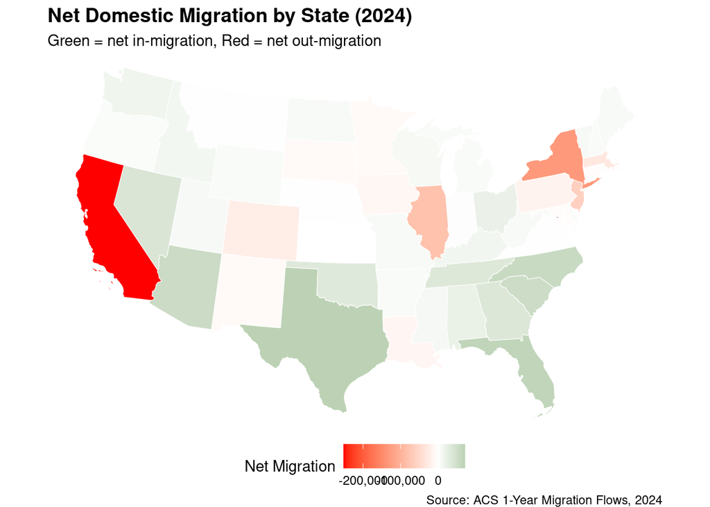

```r
library(tigris)
library(sf)

states_geo <- tigris::states(cb = TRUE, resolution = "20m", year = 2023) |>
  filter(!STUSPS %in% c("AK", "HI", "PR", "VI", "GU", "MP", "AS")) |>
  shift_geometry()
map_data <- states_geo |>
  left_join(
    state_migration_summary |>
      filter(year == 2024) |>
      rename(STUSPS = state) |>
      mutate(STUSPS = state.abb[match(STUSPS, state.name)]),
    by = "STUSPS"
  )

ggplot(map_data) +
  geom_sf(aes(fill = net_migration), color = "white", linewidth = 0.2) +
  scale_fill_gradient2(
    low = "red", mid = "white", high = "darkgreen",
    midpoint = 0, labels = scales::comma, name = "Net Migration"
  ) +
  labs(
    title    = "Net Domestic Migration by State (2024)",
    subtitle = "Green = net in-migration, Red = net out-migration",
    caption  = "Source: ACS 1-Year Migration Flows, 2024"
  ) +
  theme_void() +
  theme(plot.title = element_text(face = "bold", size = 14), legend.position = "bottom")
```

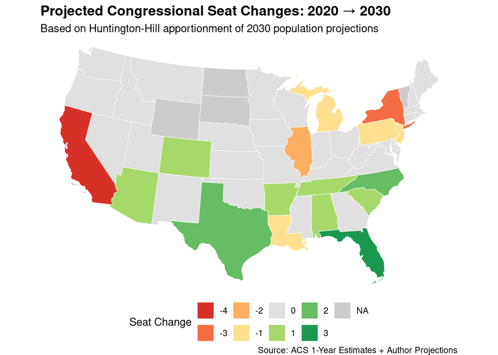

```r
map_data2 <- states_geo |>
  left_join(
    apport_comparison |> mutate(STUSPS = state.abb[match(state_name, state.name)]),
    by = "STUSPS"
  )

ggplot(map_data2) +
  geom_sf(aes(fill = factor(change)), color = "white", linewidth = 0.2) +
  scale_fill_manual(
    values = c(
      "-4" = "#d73027", "-3" = "#f46d43", "-2" = "#fdae61", "-1" = "#fee090",
      "0"  = "#e0e0e0", "1"  = "#a6d96a", "2"  = "#66bd63", "3"  = "#1a9850"
    ),
    name = "Seat Change", na.value = "grey80"
  ) +
  labs(
    title    = "Projected Congressional Seat Changes: 2020 → 2030",
    subtitle = "Based on Huntington-Hill apportionment of 2030 population projections",
    caption  = "Source: ACS 1-Year Estimates + Author Projections"
  ) +
  theme_void() +
  theme(plot.title = element_text(face = "bold", size = 14), legend.position = "bottom")
```

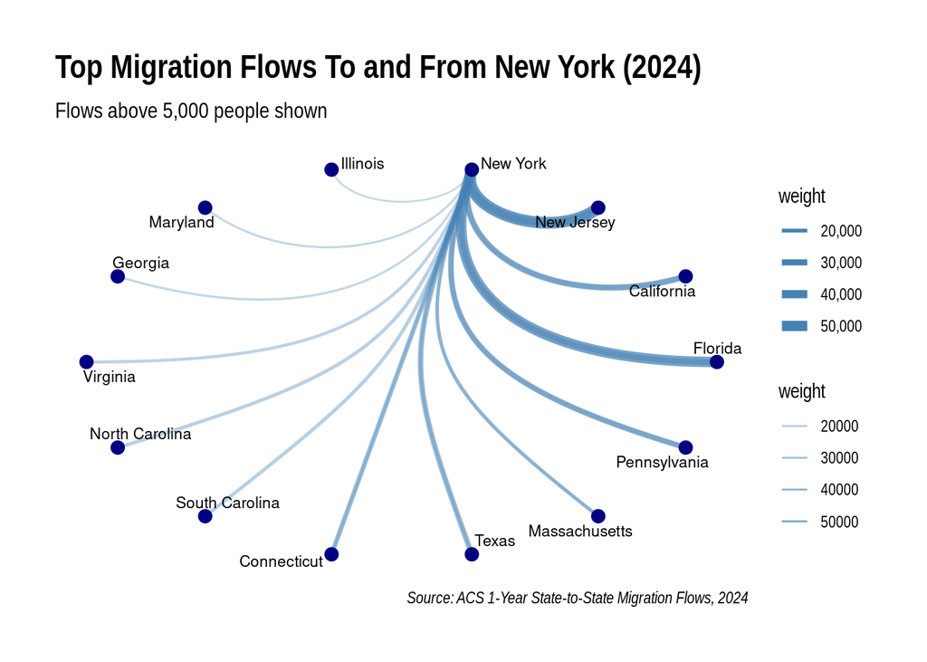

```r
library(ggraph)
library(igraph)

ny_flows <- all_flows |>
  filter(year_current == 2024,
         (state_current == "New York" | state_1y == "New York"),
         state_current != state_1y) |>
  mutate(from = state_1y, to = state_current) |>
  group_by(from, to) |>
  summarize(weight = sum(population, na.rm = TRUE), .groups = "drop") |>
  filter(weight > 5000) |>
  arrange(desc(weight)) |>
  slice_head(n = 20)

g <- graph_from_data_frame(ny_flows, directed = TRUE)

ggraph(g, layout = "linear", circular = TRUE) +
  geom_edge_arc(aes(width = weight, alpha = weight), color = "steelblue") +
  geom_node_point(size = 3, color = "navy") +
  geom_node_text(aes(label = name), repel = TRUE, size = 3) +
  scale_edge_width(range = c(0.5, 3), labels = scales::comma) +
  scale_edge_alpha(range = c(0.3, 0.8)) +
  labs(
    title    = "Top Migration Flows To and From New York (2024)",
    subtitle = "Flows above 5,000 people shown",
    caption  = "Source: ACS 1-Year State-to-State Migration Flows, 2024"
  ) +
  theme_graph()
```

## Extra Credit #03: More Realistic Growth Model

Rather than applying a single national growth rate to all states, we fit a state-specific growth rate for each state, capturing the fact that younger states (like Utah) grow faster naturally while older states (like Maine) grow more slowly.

```r
state_alpha <- state_pop_tidy |>
  filter(year %in% c(2022, 2023, 2024)) |>
  pivot_wider(names_from = year, values_from = population, names_prefix = "pop_") |>
  filter(!is.na(pop_2022), !is.na(pop_2023), !is.na(pop_2024)) |>
  mutate(
    alpha_2023 = (pop_2023 - pop_2022) / pop_2022,
    alpha_2024 = (pop_2024 - pop_2023) / pop_2023,
    alpha_avg  = (alpha_2023 + alpha_2024) / 2
  ) |>
  select(state_name, alpha_avg)

state_alpha |>
  arrange(desc(alpha_avg)) |>
  slice_head(n = 10) |>
  gt() |>
  tab_header("States with Highest Growth Rates") |>
  fmt_percent(alpha_avg, decimals = 2) |>
  cols_label(state_name = "State", alpha_avg = "Avg Annual Growth Rate")
```

States with Highest Growth Rates

| State | Avg Annual Growth Rate |
| --- | --- |
| Florida | 2.51% |
| District of Columbia | 2.25% |
| Texas | 2.08% |
| South Carolina | 1.84% |
| Utah | 1.80% |
| Delaware | 1.63% |
| North Carolina | 1.61% |
| Idaho | 1.60% |
| Arizona | 1.51% |
| Nevada | 1.41% |

```r
state_alpha |>
  arrange(alpha_avg) |>
  slice_head(n = 10) |>
  gt() |>
  tab_header("States with Lowest Growth Rates") |>
  fmt_percent(alpha_avg, decimals = 2) |>
  cols_label(state_name = "State", alpha_avg = "Avg Annual Growth Rate")
```

States with Lowest Growth Rates

| State | Avg Annual Growth Rate |
| --- | --- |
| West Virginia | −0.15% |
| Mississippi | 0.05% |
| Louisiana | 0.08% |
| Vermont | 0.11% |
| Hawaii | 0.21% |
| Oregon | 0.38% |
| New Mexico | 0.40% |
| Pennsylvania | 0.41% |
| Alaska | 0.45% |
| New York | 0.49% |

```r
project_one_year_v2 <- function(pop_df, alpha_df, mu_df) {
  net_mig <- mu_df |>
    left_join(pop_df |> rename(pop_origin = population), by = c("state_origin" = "state_name")) |>
    left_join(pop_df |> rename(pop_dest   = population), by = c("state_dest"   = "state_name")) |>
    mutate(flow = mu * pop_origin * pop_dest) |>
    group_by(state_dest) |>
    summarize(in_flow = sum(flow, na.rm = TRUE), .groups = "drop") |>
    full_join(
      mu_df |>
        left_join(pop_df |> rename(pop_origin = population), by = c("state_origin" = "state_name")) |>
        left_join(pop_df |> rename(pop_dest   = population), by = c("state_dest"   = "state_name")) |>
        mutate(flow = mu * pop_origin * pop_dest) |>
        group_by(state_origin) |>
        summarize(out_flow = sum(flow, na.rm = TRUE), .groups = "drop"),
      by = c("state_dest" = "state_origin")
    ) |>
    mutate(net_flow = replace_na(in_flow, 0) - replace_na(out_flow, 0)) |>
    rename(state_name = state_dest)

  pop_df |>
    left_join(net_mig,  by = "state_name") |>
    left_join(alpha_df, by = "state_name") |>
    mutate(
      population = population * (1 + alpha_avg) + replace_na(net_flow, 0),
      population = round(population)
    ) |>
    select(state_name, population)
}

projections_v2 <- list()
current_pop_v2 <- pop_2024

for (yr in 2025:2030) {
  current_pop_v2 <- project_one_year_v2(current_pop_v2, state_alpha, mu_avg)
  projections_v2[[as.character(yr)]] <- current_pop_v2 |> mutate(year = yr)
}

proj_df_v2   <- bind_rows(projections_v2)
proj_2030_v2 <- proj_df_v2 |> filter(year == 2030) |> arrange(desc(population))

ny_v1 <- proj_2030    |> filter(state_name == "New York") |> pull(population)
ny_v2 <- proj_2030_v2 |> filter(state_name == "New York") |> pull(population)

cat("NY 2030 projection - Base model:    ", format(ny_v1, big.mark = ","), "\n")
```

```
NY 2030 projection - Base model:     20,111,521
```

```r
cat("NY 2030 projection - Refined model: ", format(ny_v2, big.mark = ","), "\n")
```

```
NY 2030 projection - Refined model:  19,469,794
```

```r
apport_2030_v2 <- huntington_hill(proj_2030_v2 |> select(state_name, population))

apport_2020 |>
  select(state_name, districts_2020 = n_districts) |>
  full_join(apport_2030_v2 |> select(state_name, districts_2030 = n_districts), by = "state_name") |>
  mutate(change = districts_2030 - districts_2020) |>
  filter(change != 0) |>
  arrange(desc(change)) |>
  gt() |>
  tab_header("Projected Seat Changes: Refined Model (State-Specific Growth Rates)") |>
  cols_label(state_name = "State", districts_2020 = "Seats (2020)",
             districts_2030 = "Seats (2030)", change = "Change") |>
  data_color(columns = change, palette = c("red", "white", "darkgreen"), domain = c(-3, 3))
```

Projected Seat Changes: Refined Model (State-Specific Growth Rates)

| State | Seats (2020) | Seats (2030) | Change |
| --- | --- | --- | --- |
| Florida | 30 | 36 | 6 |
| Texas | 42 | 47 | 5 |
| Arizona | 9 | 11 | 2 |
| North Carolina | 14 | 16 | 2 |
| South Carolina | 6 | 8 | 2 |
| Colorado | 7 | 8 | 1 |
| Georgia | 15 | 16 | 1 |
| Tennessee | 9 | 10 | 1 |
| Iowa | 4 | 3 | -1 |
| Louisiana | 6 | 5 | -1 |
| Michigan | 14 | 13 | -1 |
| New Jersey | 13 | 12 | -1 |
| Pennsylvania | 18 | 17 | -1 |
| Virginia | 12 | 11 | -1 |
| West Virginia | 2 | 1 | -1 |
| Wisconsin | 8 | 7 | -1 |
| Illinois | 18 | 16 | -2 |
| New York | 29 | 25 | -4 |
| California | 57 | 51 | -6 |

## Extra Credit #04: Model Validation

To evaluate the reliability of our forecasting approach, we apply the same model retrospectively. Using 2018–2019 data to fit parameters, we predict state populations for 2021–2024 and compare against actual ACS estimates.

```r
pop_2018 <- get_pop_year(2018)
pop_2019 <- get_pop_year(2019)

flows_hist_file <- fs::path(data_mp03, "State_to_State_Migrations_Table_2019.xls")
if (!fs::file_exists(flows_hist_file)) {
  download.file(
    "https://www2.census.gov/programs-surveys/demo/tables/geographic-mobility/2019/state-to-state-migration/State_to_State_Migrations_Table_2019.xls",
    destfile = flows_hist_file, mode = "wb"
  )
}

states_with_dc     <- c(state.name[1:8], "District of Columbia", state.name[9:50])
raw_2019           <- read_excel(flows_hist_file, sheet = 1, skip = 8, col_names = FALSE)
estimate_cols_2019 <- seq(10, 10 + (51 * 2) - 2, by = 2)

flow_data_2019 <- raw_2019 |>
  select(state_current = 1, all_of(estimate_cols_2019)) |>
  filter(state_current %in% state.name)

colnames(flow_data_2019) <- c("state_current", states_with_dc)

flows_2019 <- flow_data_2019 |>
  pivot_longer(cols = all_of(states_with_dc), names_to = "state_1y", values_to = "population") |>
  filter(state_current != state_1y, state_1y != "District of Columbia", !is.na(population)) |>
  mutate(
    population   = replace(population, population == "N", "0"),
    population   = replace(population, population == "X", NA),
    population   = as.integer(population),
    year_current = 2019L,
    year_1y      = 2018L
  ) |>
  select(state_current, state_1y, population, year_current, year_1y)

params_hist <- fit_model_params(flows_2019, pop_2018, pop_2019, 2018L, 2019L)

proj_hist <- list()
curr <- pop_2019
for (yr in 2020:2024) {
  curr <- project_one_year(curr, params_hist$alpha, params_hist$mu)
  proj_hist[[as.character(yr)]] <- curr |> mutate(year = yr)
}

proj_hist_df <- bind_rows(proj_hist)

actuals <- state_pop_tidy |>
  filter(year %in% c(2021, 2022, 2023, 2024), state_name %in% state.name) |>
  select(state_name, year, actual = population)

validation <- proj_hist_df |>
  filter(year %in% c(2021, 2022, 2023, 2024)) |>
  rename(predicted = population) |>
  left_join(actuals, by = c("state_name", "year")) |>
  mutate(error = predicted - actual, pct_error = error / actual)

validation |>
  group_by(year) |>
  summarize(
    mean_abs_pct_error = mean(abs(pct_error), na.rm = TRUE),
    max_abs_pct_error  = max(abs(pct_error),  na.rm = TRUE),
    .groups = "drop"
  ) |>
  gt() |>
  tab_header("Model Validation: Mean Absolute Percent Error by Forecast Horizon") |>
  fmt_percent(c(mean_abs_pct_error, max_abs_pct_error), decimals = 2) |>
  cols_label(year = "Forecast Year", mean_abs_pct_error = "Mean Abs % Error",
             max_abs_pct_error = "Max Abs % Error")
```

Model Validation: Mean Absolute Percent Error by Forecast Horizon

| Forecast Year | Mean Abs % Error | Max Abs % Error |
| --- | --- | --- |
| 2021 | 3.91% | 29.85% |
| 2022 | 5.62% | 40.79% |
| 2023 | 7.23% | 49.97% |
| 2024 | 8.87% | 58.25% |

```r
avg_error_2030 <- validation |>
  filter(year == 2024) |>
  summarize(mape = mean(abs(pct_error), na.rm = TRUE)) |>
  pull(mape)

proj_2030 |>
  filter(state_name == "New York") |>
  mutate(
    lower = round(population * (1 - avg_error_2030)),
    upper = round(population * (1 + avg_error_2030))
  ) |>
  select(state_name, lower, population, upper) |>
  gt() |>
  tab_header("New York 2030 Population Projection with Margin of Error") |>
  fmt_integer(c(lower, population, upper)) |>
  cols_label(state_name = "State", lower = "Lower Bound",
             population = "Central Estimate", upper = "Upper Bound") |>
  tab_source_note(
    paste0("Margin of error (±", scales::percent(avg_error_2030, accuracy = 0.1),
           ") derived from retrospective model validation (2019→2024).")
  )
```

New York 2030 Population Projection with Margin of Error

| State | Lower Bound | Central Estimate | Upper Bound |
| --- | --- | --- | --- |
| New York | 18,328,417 | 20,111,521 | 21,894,625 |

Margin of error (±8.9%) derived from retrospective model validation (2019→2024).

**NoteAI Usage Statement**

I used generative AI tools to assist with debugging R code, resolving errors, and understanding how to implement certain data transformations and visualizations. AI was also used to help clarify coding logic and troubleshoot issues related to dataset merging and variable construction. All written explanations, interpretations, and conclusions in this report were developed independently.

*Report prepared for STA 9750, Spring 2026. Analysis focuses on New York State.*